# R4DS_2E_dataTransformation

## Data Transformation - Columns

1. Compare dep_time, sched_dep_time, and dep_delay. How would you expect those three numbers to be related?

```r
# I would expect that dep_delay should be related to the difference between sched_dep_time and dep_time. If the recorded dep_delay is accurate I would expect the difference between sched_dep_time & dep_time and dep_delay to be zero
# dep_time and sched_dep_time are both in HHMM format unlike dep_delay so we have to reconcile this. The calculation that we will need to use is most likely using the modulo operator which we haven't seen yet so I will wait to do this later on in the book
```

2. Brainstorm as many ways as possible to select dep_time, dep_delay, arr_time, and arr_delay from flights.

```r
flights |>
  select(dep_time, dep_delay, arr_time, arr_delay)
```

```
## # A tibble: 336,776 × 4
##    dep_time dep_delay arr_time arr_delay
##       <int>     <dbl>    <int>     <dbl>
##  1      517         2      830        11
##  2      533         4      850        20
##  3      542         2      923        33
##  4      544        -1     1004       -18
##  5      554        -6      812       -25
##  6      554        -4      740        12
##  7      555        -5      913        19
##  8      557        -3      709       -14
##  9      557        -3      838        -8
## 10      558        -2      753         8
## # ℹ 336,766 more rows
```

```r
# There are a bunch of other ways. We could fo dep_time:arr_delay and drop the scheduled time columns, we could remove every column that is not dep_time, dep_delay, arr_time or arr_delay, but all these other methods seem much more tedious and unnecessary than the simple select statement above.
```

3. What happens if you specify the name of the same variable multiple times in a select() call?

```r
flights |>
  select(dep_time, dep_time, arr_time)
```

```
## # A tibble: 336,776 × 2
##    dep_time arr_time
##       <int>    <int>
##  1      517      830
##  2      533      850
##  3      542      923
##  4      544     1004
##  5      554      812
##  6      554      740
##  7      555      913
##  8      557      709
##  9      557      838
## 10      558      753
## # ℹ 336,766 more rows
```

```r
# It ignores the fact that the same variable was used multiple times and simply acts as though the variable was called upon  once.
```

4. What does the any_of() function do? Why might it be helpful in conjunction with this vector?

```r
variables <- c("year", "month", "day", "dep_delay", "arr_delay")
flights |>
  select(any_of(variables))
```

```
## # A tibble: 336,776 × 5
##     year month   day dep_delay arr_delay
##    <int> <int> <int>     <dbl>     <dbl>
##  1  2013     1     1         2        11
##  2  2013     1     1         4        20
##  3  2013     1     1         2        33
##  4  2013     1     1        -1       -18
##  5  2013     1     1        -6       -25
##  6  2013     1     1        -4        12
##  7  2013     1     1        -5        19
##  8  2013     1     1        -3       -14
##  9  2013     1     1        -3        -8
## 10  2013     1     1        -2         8
## # ℹ 336,766 more rows
```

```r
# `any_of()` must be used with a selecting function. It can be helpful since we can specify variables outside of our pipe function for enhanced readability but from the documentation it can also be especially useful with negative selections, when you would like to make sure a variable is removed
```

5. Does the result of running the following code surprise you? How do the select helpers deal with upper and lower case by default? How can you change that default?

```r
flights |> select(contains("TIME"))
```

```
## # A tibble: 336,776 × 6
##    dep_time sched_dep_time arr_time sched_arr_time air_time time_hour
##       <int>          <int>    <int>          <int>    <dbl> <dttm>
##  1      517            515      830            819      227 2013-01-01 05:00:00
##  2      533            529      850            830      227 2013-01-01 05:00:00
##  3      542            540      923            850      160 2013-01-01 05:00:00
##  4      544            545     1004           1022      183 2013-01-01 05:00:00
##  5      554            600      812            837      116 2013-01-01 06:00:00
##  6      554            558      740            728      150 2013-01-01 05:00:00
##  7      555            600      913            854      158 2013-01-01 06:00:00
##  8      557            600      709            723       53 2013-01-01 06:00:00
##  9      557            600      838            846      140 2013-01-01 06:00:00
## 10      558            600      753            745      138 2013-01-01 06:00:00
## # ℹ 336,766 more rows
```

```r
# It does surprise me a little. The text within `contains` is not case sensitive by default which can cause potential problems. `contains` has the default argument of `ignore.case = TRUE` so we simply set it to FALSE
flights |> select(contains("TIME", FALSE))
```

```
## # A tibble: 336,776 × 0
```

6. Rename air_time to air_time_min to indicate units of measurement and move it to the beginning of the data frame.

```r
flights |>
  relocate(air_time_min = air_time)
```

```
## # A tibble: 336,776 × 19
##    air_time_min  year month   day dep_time sched_dep_time dep_delay arr_time
##           <dbl> <int> <int> <int>    <int>          <int>     <dbl>    <int>
##  1          227  2013     1     1      517            515         2      830
##  2          227  2013     1     1      533            529         4      850
##  3          160  2013     1     1      542            540         2      923
##  4          183  2013     1     1      544            545        -1     1004
##  5          116  2013     1     1      554            600        -6      812
##  6          150  2013     1     1      554            558        -4      740
##  7          158  2013     1     1      555            600        -5      913
##  8           53  2013     1     1      557            600        -3      709
##  9          140  2013     1     1      557            600        -3      838
## 10          138  2013     1     1      558            600        -2      753
## # ℹ 336,766 more rows
## # ℹ 11 more variables: sched_arr_time <int>, arr_delay <dbl>, carrier <chr>,
## #   flight <int>, tailnum <chr>, origin <chr>, dest <chr>, distance <dbl>,
## #   hour <dbl>, minute <dbl>, time_hour <dttm>
```

7. Why doesn’t the following work, and what does the error mean?

```r
##flights |>
##  select(tailnum) |>
##  arrange(arr_delay)
# Select creates a new dataframe solely with the variable tailnum as specified, so when we call on the arrange function to arrange by arr_delay this simply isn't possible as arr_delay isn't present in our new subsetted dataframe.
```

## Data Transformation - Groups

1. Which carrier has the worst average delays? Challenge: can you disentangle the effects of bad airports vs. bad carriers? Why/why not? (Hint: think about flights |> group_by(carrier, dest) |> summarize(n()))

```r
# We can choose dep_delay or arr_delay. I will choose arr_delay as delayed time when departing can be made up through air time.
flights |>
  summarize(
    avg_delay = mean(arr_delay, na.rm = TRUE),
    .by = carrier
  ) |>
  arrange(desc(avg_delay))
```

```
## # A tibble: 16 × 2
##    carrier avg_delay
##    <chr>       <dbl>
##  1 F9         21.9
##  2 FL         20.1
##  3 EV         15.8
##  4 YV         15.6
##  5 OO         11.9
##  6 MQ         10.8
##  7 WN          9.65
##  8 B6          9.46
##  9 9E          7.38
## 10 UA          3.56
## 11 US          2.13
## 12 VX          1.76
## 13 DL          1.64
## 14 AA          0.364
## 15 HA         -6.92
## 16 AS         -9.93
```

```r
# Carrier F9 has the worst average delay of about 22 minutes
```

```r
flights |> group_by(carrier, dest) |> summarize(n())
```

```
## # A tibble: 314 × 3
## # Groups:   carrier [16]
##    carrier dest  `n()`
##    <chr>   <chr> <int>
##  1 9E      ATL      59
##  2 9E      AUS       2
##  3 9E      AVL      10
##  4 9E      BGR       1
##  5 9E      BNA     474
##  6 9E      BOS     914
##  7 9E      BTV       2
##  8 9E      BUF     833
##  9 9E      BWI     856
## 10 9E      CAE       3
## # ℹ 304 more rows
```

```r
# Looking over the above and finding the carrier F9, we see that the F9 carrier only has the destination of DEN. So it appears that there is equal likelihood that the airport that the F9 carrier is leaving from is to blame for the large amount of delays. However it is hard to say for certain, we would probably want to look at the average delay of each destination. If DEN has high average delay then this is further supporting evidence that DEN is a bad airport in terms of delays.

flights |>
  summarize(
    avg_delay = mean(arr_delay, na.rm = TRUE),
    .by = dest
  ) |>
  arrange(desc(avg_delay))
```

```
## # A tibble: 105 × 2
##    dest  avg_delay
##    <chr>     <dbl>
##  1 CAE        41.8
##  2 TUL        33.7
##  3 OKC        30.6
##  4 JAC        28.1
##  5 TYS        24.1
##  6 MSN        20.2
##  7 RIC        20.1
##  8 CAK        19.7
##  9 DSM        19.0
## 10 GRR        18.2
## # ℹ 95 more rows
```

```r
# DEN is about the 49th highest airport in terms of arr_delay, at a value of 8.61. This is a stark difference from the F9 delay of 22, so seemingly it might actually be the carrier's fault in this situation for the delay. But again, I'm not 100% sure how you would go about identifying whether its the carrier or airport fault.
```

2. Find the flights that are most delayed upon departure from each destination.

```r
# We'll have to use dep_delay in this instance since we are looking at MOST delayed UPON departure. Note there are 105 unique destinations
flights |>
  group_by(dest) |>
  slice_max(dep_delay, n = 1) |>
  relocate(dest, dep_delay)
```

```
## # A tibble: 105 × 19
## # Groups:   dest [105]
##    dest  dep_delay  year month   day dep_time sched_dep_time arr_time
##    <chr>     <dbl> <int> <int> <int>    <int>          <int>    <int>
##  1 ABQ         142  2013    12    14     2223           2001      133
##  2 ACK         219  2013     7    23     1139            800     1250
##  3 ALB         323  2013     1    25      123           2000      229
##  4 ANC          75  2013     8    17     1740           1625     2042
##  5 ATL         898  2013     7    22     2257            759      121
##  6 AUS         351  2013     7    10     2056           1505     2347
##  7 AVL         222  2013     6    14     1158            816     1335
##  8 BDL         252  2013     2    21     1728           1316     1839
##  9 BGR         248  2013    12     1     1504           1056     1628
## 10 BHM         325  2013     4    10       25           1900      136
## # ℹ 95 more rows
## # ℹ 11 more variables: sched_arr_time <int>, arr_delay <dbl>, carrier <chr>,
## #   flight <int>, tailnum <chr>, origin <chr>, air_time <dbl>, distance <dbl>,
## #   hour <dbl>, minute <dbl>, time_hour <dttm>
```

3. How do delays vary over the course of the day. Illustrate your answer with a plot.

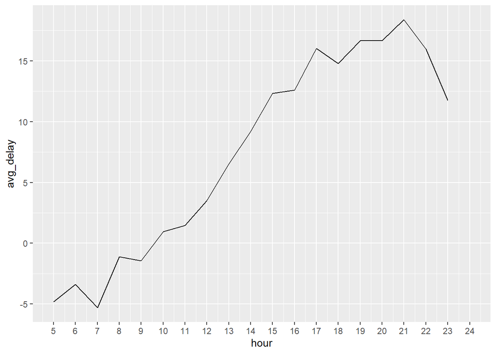

```r
# I'll group by each hour and choose arr_delay over dep_delay due to reasons mentioned previously
flights |>
  summarize(
    avg_delay = mean(arr_delay, na.rm = TRUE),
    .by = hour
  ) |>
ggplot(aes(x = hour, y = avg_delay)) +
geom_line() +
scale_x_continuous(breaks = seq(5, 24), limits = c(5, 24)) # Ignore below 5 am since missing values
```